# Workshop II: Classification with Logistic Regression

Benjamin Burquier

October 2024

# 1 Introduction

Welcome to the second workshop. We will continue working with the Lending Club data. In this workshop we will take the perspective of an investor to the lending club. Our goal is to select a subset of the most promising loans to invest in. We will do so using the method of logistic regression. Feel free to consult the RMD file of the session we had on logistic regression.

In answering the questions below be succinct but provide complete answers with quantitative evidence as far as possible. Feel free to discuss methods with each other and with the tutors during the workshop. As this is an individual assignment, *do not collaborate* in answering the questions below or in making investment choices.

*Please knit your RMD to an **HTML*** file. Please submit your *HTML* file **and** **CSV** file (for Q17). The deadline is 31st October 2024 at 11:59pm. 25% of your grade will depend on the performance of your investment choices (i.e., Q17). Please note that there is a 20% penalty on your individual assignment grade if you submit an RMD file.

Enjoy the workshop!

## 1.1 Load the data

First we need to start by loading the data.

```r
lc_raw <- read_csv("LendingClub Data.csv",  skip=1) %>%  #since the first row is a title we want to skip it.
  clean_names() # use janitor::clean_names()
```

# 2 ICE the data: Inspect, Clean, Explore

Any data science engagement starts with ICE. Inspecting, Clean and Explore the data.

## 2.1 Inspect the data

Inspect the data to understand what different variables mean. Variable definitions can be found in the excel version of the data.

```r
glimpse(lc_raw)
```

```
## Rows: 42,538
## Columns: 80
## $ int_rate            <dbl> 0.05, 0.05, 0.05, 0.05, 0.05, 0.05, 0.05, 0.05, 0.…
## $ loan_amnt           <dbl> 8000, 6000, 6500, 8000, 5500, 6000, 10200, 15000, …
## $ term_months         <dbl> 36, 36, 36, 36, 36, 36, 36, 36, 36, 36, 36, 36, 36…
## $ installment         <dbl> 241.28, 180.96, 196.04, 241.28, 165.88, 180.96, 30…
## $ dti                 <dbl> 2.11, 5.73, 17.68, 22.71, 5.75, 21.92, 18.62, 9.72…
## $ delinq_2yrs         <dbl> 0, 0, 0, 0, 0, 0, 0, 0, 0, 0, 0, 0, 0, 0, 0, 0, 0,…
## $ annual_inc          <dbl> 50000, 52800, 35352, 79200, 240000, 89000, 110000,…
## $ grade               <chr> "A", "A", "A", "A", "A", "A", "A", "A", "A", "A", …
## $ emp_title           <chr> NA, "coral graphics", NA, "Honeywell", "O T Plus, …
## $ emp_length          <chr> "5 years", "< 1 year", "n/a", "n/a", "10+ years", …
## $ home_ownership      <chr> "MORTGAGE", "MORTGAGE", "MORTGAGE", "MORTGAGE", "M…
## $ verification_status <chr> "Verified", "Source Verified", "Not Verified", "Ve…
## $ issue_d             <chr> "9/1/2011", "9/1/2011", "9/1/2011", "9/1/2011", "9…
```

[output cut: 67 more lines]

## 2.2 Clean the data

Are there any redundant columns and rows? Are all the variables in the correct format (e.g., numeric, factor, date)? Lets fix it.

The variable `loan_status` contains information as to whether the loan has been repaid or charged off (i.e., defaulted). Let’s create a binary factor variable for this. This variable will be the focus of this workshop.

```r
lc_clean<- lc_raw %>%
  select(-where(~ mean(is.na(.)) > 0.9)) %>% # drop columns with more than 90% missing data
  filter(!is.na(int_rate)) %>%   #delete empty rows
  mutate(
    issue_d = mdy(issue_d),  # lubridate::mdy() to fix date format
    term = factor(term_months),     # turn 'term' into a categorical variable
    delinq_2yrs = factor(delinq_2yrs) # turn 'delinq_2yrs' into a categorical variable
  ) %>%
  mutate(default = dplyr::recode(loan_status,
                      "Charged Off" = "1",
                      "Fully Paid" = "0"))%>%
    mutate(default = as.factor(default)) %>%
  dplyr::select(-emp_title,-installment, -term_months, everything()) #move some not-so-important variables to the end.
```

## 2.3 Explore the data **(Q1)**

Let’s explore loan defaults by creating different visualizations. We start with examining how prevalent defaults are, whether the default rate changes by loan grade or number of delinquencies, and a couple of scatter plots of defaults against loan amount and income.

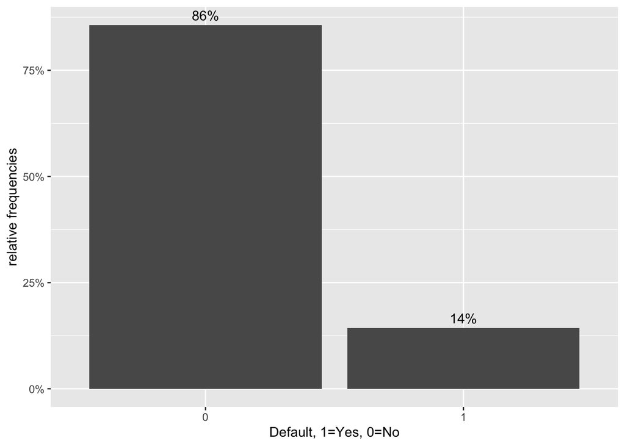

```r
#bar chart of defaults
def_vis1<-ggplot(data=lc_clean, aes(x=default)) +geom_bar(aes(y = (..count..)/sum(..count..))) + labs(x="Default, 1=Yes, 0=No", y="relative frequencies") +scale_y_continuous(labels=scales::percent) +geom_text(aes( label = scales::percent((..count..)/sum(..count..) ),y=(..count..)/sum(..count..) ), stat= "count",vjust=-0.5)
def_vis1
```

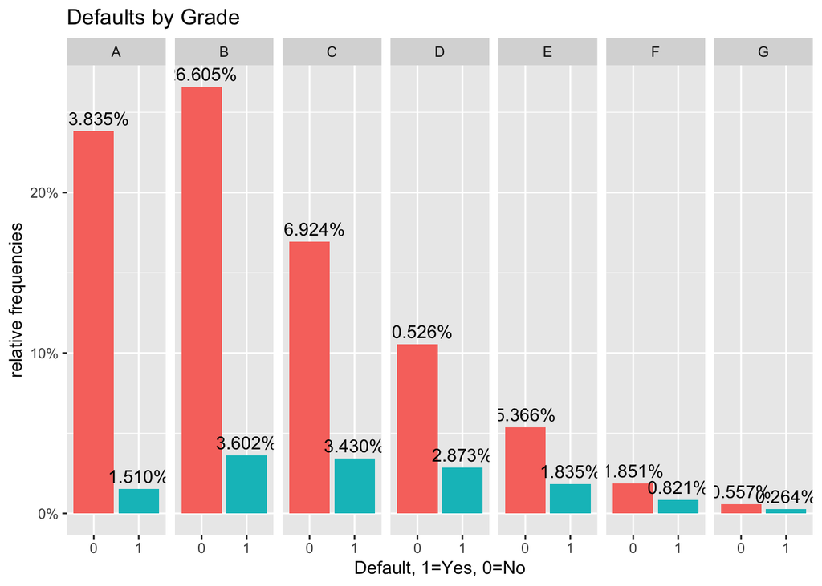

```r
#bar chart of defaults per loan grade
def_vis2<-ggplot(data=lc_clean, aes(x=default), group=grade) +geom_bar(aes(y = (..count..)/sum(..count..), fill = factor(..x..)), stat="count")  + labs(title="Defaults by Grade", x="Default, 1=Yes, 0=No", y="relative frequencies") +scale_y_continuous(labels=scales::percent) +facet_grid(~grade) + theme(legend.position = "none") +geom_text(aes( label = scales::percent((..count..)/sum(..count..) ),y=(..count..)/sum(..count..) ), stat= "count",vjust=-0.5)
def_vis2
```

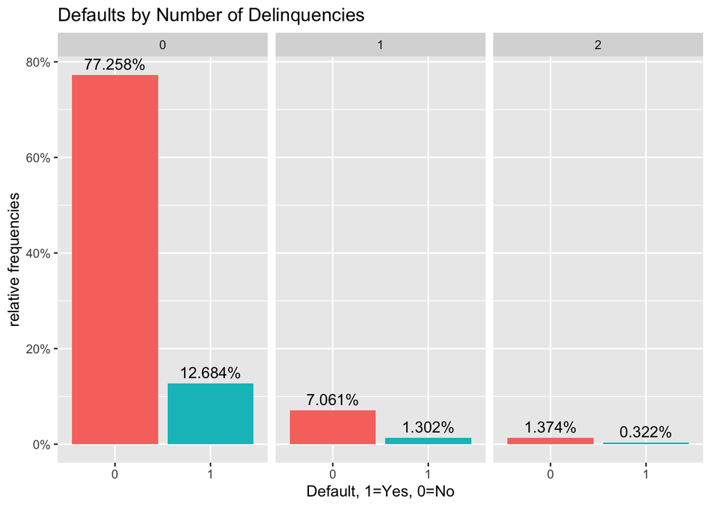

```r
#bar chart of defaults per number of Delinquencies
def_vis3<-lc_clean %>%
  filter(as.numeric(delinq_2yrs)<4) %>%
  ggplot(aes(x=default), group=delinq_2yrs) +geom_bar(aes(y = (..count..)/sum(..count..), fill = factor(..x..)), stat="count")  + labs(title="Defaults by Number of Delinquencies", x="Default, 1=Yes, 0=No", y="relative frequencies")  +scale_y_continuous(labels=scales::percent) +facet_grid(~delinq_2yrs) + theme(legend.position = "none") +geom_text(aes( label = scales::percent((..count..)/sum(..count..) ),y=(..count..)/sum(..count..) ), stat= "count",vjust=-0.5)

def_vis3
```

[figure not shown]

```r
#scatter plots

#We select 2000 random loans to display only to make the display less busy.
set.seed(1234)
reduced<-lc_clean[sample(0:nrow(lc_clean), 2000, replace = FALSE),]%>%
  mutate(default=as.numeric(default)-1) # also convert default to a numeric {0,1} to make it easier to plot.


# scatter plot of defaults against loan amount
# If the jitter plot does not show up, try to remove I() and simply use x=loan_amnt/1000
def_vis4<-ggplot(data=reduced, aes(y=default,x=I(loan_amnt/1000)))  + labs(y="Default, 1=Yes, 0=No", x="Loan Amnt (1000 $)") +geom_jitter(width=0, height=0.05, alpha=0.7) #We use jitter to offset the display of defaults/non-defaults to make the data easier to interpert. We have also changed the amount to 1000$ to reduce the number of zeros on the horizontal axis.

def_vis4
```

[figure not shown]

```r
#scatter plot of defaults against loan amount.
def_vis5<-ggplot(data=reduced, aes(y=default,x=I(annual_inc/1000)))   + labs(y="Default, 1=Yes, 0=No", x="Annual Income(1000 $)") +geom_jitter(width=0, height=0.05, alpha=0.7) +  xlim(0,400)

def_vis5
```

We can also estimate a correlation table between defaults and other continuous variables.

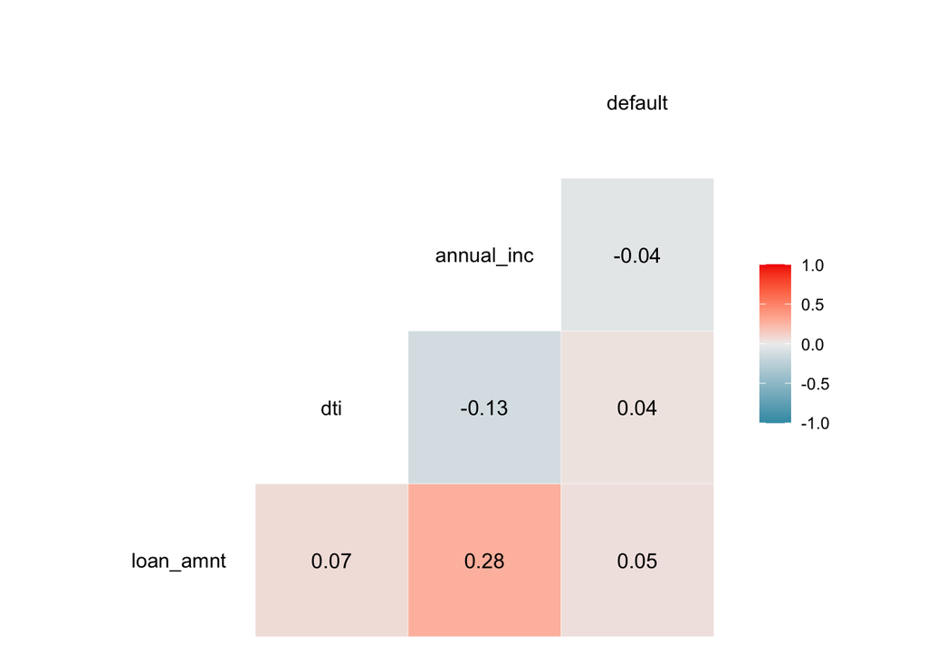

```r
# correlation table using GGally::ggcor()
# this takes a while to plot

lc_clean %>%
    mutate(default=as.numeric(default)-1)%>%
  select(loan_amnt, dti, annual_inc, default) %>% #keep Y variable last
 ggcorr(method = c("pairwise", "pearson"), label_round=2, label = TRUE)
```

> **Q1**. Add **one more** visualization of your own. Describe what it shows and what you learn from it in 1-2 lines.

Insert your code here:

```r
# My visualization
def_vis9 <- ggplot(lc_clean, aes(x = loan_amnt, fill = default)) +
  geom_density(alpha = 0.5) +
  labs(title = "Distribution of Loan Amount by Default Status",
       x = "Loan Amount ($)",
       y = "Density",
       fill = "Default (1 = Yes, 0 = No)") +
  theme_minimal()

def_vis9
```

[output not shown]

*Insert comments here:* The following is a density plot of the loan amount distribution for loans that have defaulted (1) or not defaulted (0). This will show how similar in loan amount the two categories overlap, since we can see if there are clear trends. For example, if at a certain loan amounts the density for defaulted loans is higher, that may indicate that borrowers with loans in that range are more likely to default.

# 3 Linear vs. logistic regression for binary response variables **(Q2)**

It is certainly possible to use the OLS approach to find the line that minimizes the sum of squared errors when the dependent variable is binary (i.e., default / no default). In this case, the predicted values take the interpretation of a probability. We can also estimate a logistic regression instead. We do both below.

```r
model_lm<-lm(as.numeric(default)~I(annual_inc/1000), lc_clean)
summary(model_lm)
```

```
##
## Call:
## lm(formula = as.numeric(default) ~ I(annual_inc/1000), data = lc_clean)
##
## Residuals:
##     Min      1Q  Median      3Q     Max
## -0.1595 -0.1494 -0.1444 -0.1332  1.3268
##
## Coefficients:
##                      Estimate Std. Error t value Pr(>|t|)
## (Intercept)         1.161e+00  2.703e-03 429.312   <2e-16 ***
## I(annual_inc/1000) -2.479e-04  2.918e-05  -8.496   <2e-16 ***
## ---
## Signif. codes:  0 '***' 0.001 '**' 0.01 '*' 0.05 '.' 0.1 ' ' 1
##
## Residual standard error: 0.3501 on 37867 degrees of freedom
## Multiple R-squared:  0.001903,   Adjusted R-squared:  0.001876
## F-statistic: 72.19 on 1 and 37867 DF,  p-value: < 2.2e-16
```

```r
logistic1<-glm(default~I(annual_inc/1000), family="binomial", lc_clean)
summary(logistic1)
```

```
##
## Call:
## glm(formula = default ~ I(annual_inc/1000), family = "binomial",
##     data = lc_clean)
##
## Coefficients:
##                      Estimate Std. Error z value Pr(>|z|)
## (Intercept)        -1.5191545  0.0292430  -51.95   <2e-16 ***
## I(annual_inc/1000) -0.0040801  0.0003998  -10.21   <2e-16 ***
## ---
## Signif. codes:  0 '***' 0.001 '**' 0.01 '*' 0.05 '.' 0.1 ' ' 1
##
## (Dispersion parameter for binomial family taken to be 1)
##
##     Null deviance: 31130  on 37868  degrees of freedom
## Residual deviance: 31005  on 37867  degrees of freedom
## AIC: 31009
##
## Number of Fisher Scoring iterations: 5
```

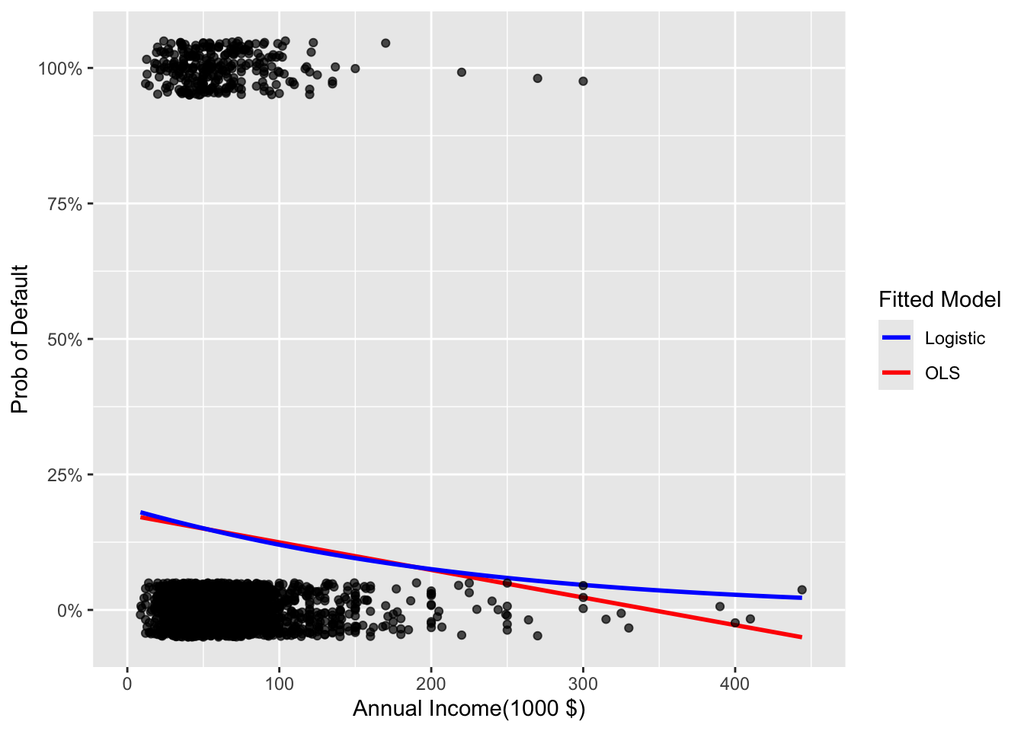

```r
ggplot(data=reduced, aes(x=annual_inc/1000, y=default)) + geom_smooth(method="lm", se=0, aes(color="OLS"))+ geom_smooth(method = "glm", method.args = list(family = "binomial"),  se=0, aes(color="Logistic"))+ labs(y="Prob of Default", x="Annual Income(1000 $)")+  xlim(0,450)+scale_y_continuous(labels=scales::percent)+geom_jitter(width=0, height=0.05, alpha=0.7) + scale_colour_manual(name="Fitted Model", values=c("blue", "red"))
```

> **Q2**. Which model is more suitable for predicting probability of default, the linear regression or the logistic? Why?

Answer here: Logistic regression turns out to be more suitable in the prediction of probability because it constrains the prediction within 0 and 1, making the prediction interpretable as probabilities. Moreover, it models the relationship in a nonlinear way, capturing better the nature of binary outcomes.

# 4 Multivariate logistic regression **(Q3, Q4)**

We can estimate logistic regression with multiple explanatory variables as well. Let’s use `annual_inc`, `term`, `grade`, and `loan_amnt` as features. Let’s call this model `logistic2`.

```r
logistic2 <- glm(default ~ annual_inc + term + grade + loan_amnt, family = "binomial", data = lc_clean)
summary(logistic2)

#compare the fit of logistic 1 & logistic 2
anova(logistic1,logistic2, test = "Chisq")
```

[output not shown]

> **Q3**. Based on logistic 2, explain the following:  
> a. Explain briefly the logic of MLE (maximum likelihood estimation).  
> b. What does the standard error of a coefficient mean?  
> c. What does the p-value of a coefficient mean?  
> d. What does deviance mean?  
> e. What does AIC mean?  
> f. What does null deviance mean?  
> g. Is Logistic 2 a better model than logistic 1? Why or why not?

Answer here: a. Maximum likelihood estimation estimates the model parameters by finding the values that maximize the likelihood of observing the given data. For logistic regression, MLE seeks the coefficients that maximize the probability of correctly predicting the observed binary outcomes. b. The standard error of a coefficient measures the precision of the coefficient estimate. A smaller standard error indicates that the estimate is more precise, whereas a larger standard error suggests greater uncertainty in the estimate. c. The p-value assesses whether the coefficient is significantly different from zero. A low p-value (typically < 0.05) indicates that the variable has a statistically significant impact on the outcome, suggesting that it likely contributes to predicting the probability of default. d. Deviance measures the model’s fit to the data; it quantifies the discrepancy between the observed outcomes and the model’s predictions. Lower deviance indicates a better fit to the data. e. AIC (Akaike Information Criterion) is a metric used for model selection that balances goodness of fit with model complexity. Lower AIC values indicate a better model by favoring models with fewer parameters while achieving a good fit. f. Null deviance represents the deviance of a model that includes only the intercept, providing a baseline measure of how well a “no predictor” model fits the data. g. Yes, Logistic 2 is a better model than Logistic 1, as indicated by the ANOVA test with test = “Chisq”, which shows a significant reduction in deviance (p < 2.2e-16). This implies that adding more variables (e.g. annual income, term, grade, loan amount) meaningfully improves the model’s fit to the data.

> **Q4**. Calculate the predicted probabilities associated with logistic 2 and plot them as a density chart. Also plot the density of the predictions for those loans that did default, and for the loans that did not (on the same chart).

Insert your code here:

```r
#Predict the probability of default
prob_default2<-predict(logistic2, type = "response")

# Adding predicted probabilities to the data
lc_clean <- lc_clean %>% mutate(predicted_prob_default2 = prob_default2)

#plot 1: Density of predictions
density_plot <- ggplot(lc_clean, aes(x = predicted_prob_default2)) +
  geom_density(fill = "red", alpha = 0.6) +
  labs(title = "Density of Predicted Probabilities (Logistic 2)", x = "Predicted Probability of Default", y = "Density") +
  theme_minimal()

density_plot

#plot 2: Density of predictions by default
density_by_default <- ggplot(lc_clean, aes(x = predicted_prob_default2, fill = default)) +
  geom_density(alpha = 0.6) +
  labs(title = "Density of Predictions by Default", x = "Predicted Probability of Default", y = "Density") +
  scale_fill_manual(values = c("0" = "blue", "1" = "yellow"), labels = c("No Default", "Default")) +
  theme_minimal() +
  theme(legend.title = element_blank())

density_by_default
```

[output not shown]

## 4.1 From probability to classification **(Q5-Q10)**

The logistic regression model gives us a sense of how likely defaults are; it gives us a probability estimate. To convert this into a prediction, we need to choose a cutoff probability and classify every loan with a predicted probability of default above the cutoff as a prediction of default (and vice versa for loans with a predicted probability below this cutoff).

Let’s choose a threshold of 16%. Of course some of our predictions will turn out to be right but some will turn out to be wrong – you can see this in the density figures of the previous section. Let’s call “default” the “positive” class since this is the class we are trying to predict. We could be making two types of mistakes. False positives (*i.e.,* predict that a loan will default when it will not) and false negatives (*i.e.,* predict that a loan will not default when it does). These errors are summarized in the confusion matrix.

> **Q5**. Produce the confusion matrix for the model logistic 2 for a cutoff of 16%

Insert your code here:

```r
#using the logistic2 model predict default probabilities
prob_default2 <- predict(logistic2, type = "response")

#classify based onb 16% cutoff
p_class <- ifelse(prob_default2 > 0.16, "1", "0")
p_class <- factor(p_class, levels = levels(lc_clean$default))

#produce the confusion matrix
con2 <- caret::confusionMatrix(p_class, lc_clean$default, positive = "1")
con2
```

[output not shown]

> **Q6**. Using the confusion matrix, explain the following and show how they are calculated **a.1**. Accuracy **a.2.** Sensitivity **a.3.** Specificity For each of this explain what they mean in the context of the lending club and the goal of predicting loan defaults.

> **b.** Moreover, compare each of these three statistics with the two extreme models: the models that predict that every instance is “no default”/“default”.

Answer here:

Termination: TP = true positive, TN = true negative, FP = false positive, FN = false negative, TP+TN+FP+FN = TPred.

a.1. the accuracy formula is = (TP+TN)/(TPred). (TP+TN) = 3225 + 21603 = 24828. Here (TPred) = 3225 + 21603 + 10837 + 2204 = 37869. So we have 24828/37869 = approx 0.6556. the accuracy represents the proportion of correct predictions for both defaults and non-defaults (grouped) i.e. in the case on the lending club, it indicates that 65.56% of the time, the model correctly classifies a loan in either default or non-default.

a.2. sensitivity is the proportion of actual defaults that the model correctly identifies, and its formula is = TP/(TP+FN). Here, TP = 3225 ; TP+FN = 3225 + 2204 = 5429 ; TP/(TP+FN) = 3225/5429 = approx 0.5940. This means that here, the model identifies approx 59.4% of loans that truly default. in the context ofd the lending club, it is essential to have a high sensitivity as it indicates that few defaults are missed by the model and can avoid lenders risky investments.

a.3. specificity is the proportion of actual non-defaults that thge model correctly identifies and its formula is = TN/(TN+FP). Here, TN = 21603 ; TN+FP = 21603 + 10837 = 32440 ; TN/(TN+FP) = 21603/32440 = approx 0.6659. This means that here, the model identifies approx 66.59% of loans that do not default. in the context of the lenfing club, a high specificity % reduces false positives i.e. it avoids wrongfully identifying safe loans as risky.

2. Model predicting all “no default”:
- Accuracy: according to the statistics in the confusion matrix, 85.66% of loans are non-defaults, therefore this model would have an accuracy of 85.66%.
- Sensitivity: it would be 0% because it always predicts “no defaults”, thereby failing to identify “defaults”.
- Specificity: 100% because it correctly identifies all non-defaults. The all no default model is risky for the lending club because although it avoids false positives (which is good), it fails to identify actual defaults. Model predicting all “default”:
- Accuracy: this model would have an accuracy of 14.34% as only this proportion of loans actually default (100-85.66).
- Sensitivity: 100% as it correctly identifies all defaults.
- Specificity: 0% as it only identifies defaults and not non-defaults at all. The all default model increases the number of false positives as although it identifies every defauult, it classifies non-defaults as risky.

> **Q7**. Repeat Q5 & Q6.a for the cutoff being 20%. Interpret the results. Is this cutoff a better choice? In the context of lending club, explain in what situation one might be interested in a high cutoff.

```r
p_class_updated<-ifelse(prob_default2 > 0.20, "1", "0")
p_class_updated<-factor(p_class_updated, levels = levels(lc_clean$default))

#produce the confusion matrix and set default as the positive outcome
con2_updated<-caret::confusionMatrix(p_class_updated, lc_clean$default, positive = "1")
con2_updated
```

[output not shown]

Provide comments here:

Accuracy = 75.81%. The higher cutoff of 20% increased accuracy from 65.56% at 16% cutoff, ie the model is more conservative and therefore correctly identifies more non-default loans. However, it also means that it might miss some default loans.

Sensitivity = 39.22%. It dropped compared to the 59.4% of the 16% cutoff, ie the model missed more defaulted loans. Therefore, a 20% cutoff is less efficient when it comes to identifying defaults thereby undermining lenders who might be more exposed to risky loans.

Specificity = 81.94%. It is higher than the 16% cutoff which had specificity 66.59%, ie it identifies non-default loans better. This reduces missed investment opportunities for lenders.

> **Q8**. Previously, we compared the performance of the `logistic2` model with different cutoff values (16% and 20%). Recall that the concept of ROC curves roughly lets us do this analysis for more cutoff values. Using the model `logistic2` produce the ROC curve and calculate the AUC measure. Explain what the ROC shows and what the AUC measure means. Why do we expect the AUC of any predictive model to be between 0.5 and 1? Could the AUC ever be below 0.5 or above 1?

Insert your code here:

```r
#estimate the ROC curve for L2
ROC_logistic2 <- roc(lc_clean$default, prob_default2)

#estimate the AUC for L2
AUC2<-auc(ROC_logistic2)
#plot the ROC curve & display the AUC in the title
ROC2<-ggroc(ROC_logistic2) +
        labs(title = paste("ROC Curve for Logistic2 (AUC =", round(AUC2, 2), ")")) +
        theme_minimal()

ROC2
```

[output not shown]

Provide comments here: this ROC curve shows that as the model becomes more sensitive (better at predicting defaults), it sacrifices specificity (ie causing an increase in false positives). The model’s moderate AUC score indicates that it is quite effective but leaves room for improvement, suggesting that further model refinement or additional features could improve predictive accuracy.

> **Q9**. So far we have only worked in-sample. Split the data into training and testing and estimate the models ROC curve and AUC measure out of sample. Is there any evidence of overfitting?

Insert your code here:

```r
# splitting the data into training and testing
set.seed(47)
train_test_split <- initial_split(lc_clean, prop = 0.8)
testing <- testing(train_test_split) #20% of the data is set aside for testing
training <- training(train_test_split) #80% of the data is set aside for training

#run logistic 2 on the training set
logistic2_train <- glm(default ~ annual_inc + term + grade + loan_amnt, family = "binomial", data = training)

#calculate probability of default in the training sample
p_in<-predict(logistic2_train, type = "response", newdata = training)

#ROC curve using in-sample predictions
ROC_logistic2_in <- roc(training$default, p_in)

#AUC using in-sample predictions
AUC_logistic2_in<-auc(ROC_logistic2_in)

#calculate probability of default out of sample
p_out<-predict(logistic2_train, type = "response", newdata = testing)

#ROC curve using out-of-sample predictions
ROC_logistic2_out <- roc(testing$default, p_out)
#AUC using out-of-sample predictions
AUC_logistic2_out<-auc(ROC_logistic2_out)

#plot in the same figure both ROC curves and print the AUC of both curves in the title
ggroc(list(InSample = ROC_logistic2_in, OutSample = ROC_logistic2_out)) +
  labs(title = paste("ROC Curves (In-sample AUC =", round(AUC_logistic2_in, 2),
                     ", Out-of-sample AUC =", round(AUC_logistic2_out, 2), ")")) +
  theme_minimal()
```

[output not shown]

Provide comments here: overfitting evidence: if in-sample AUC is significantly higher than out-of-sample AUC, it suggests potential overfitting, as the model performs worse on unseen data.

> **Q10**.Iterate the previous experiment again. This time, however, include 500 variables to `lc_clean` **before** applying a training:test set split, and generate these variables purely at random (*e.g.*, each element of each variable is iid sampled from a zero-mean normal distribution with a standard deviation of 100). Use the previous 4 variables as well as the new 500 variables to predict `default` via logistic regression, as before. Check if the difference between the in-sample and out-of-sample AUC areas have changed positively or negatively – explain the reason behind your observation.

```r
#add 500 random noise variables to the dataset
set.seed(58)
noise_variables <- replicate(500, rnorm(n = nrow(lc_clean), mean = 0, sd = 100))
lending_data_with_noise <- cbind(lc_clean %>%
                                   select(default, annual_inc, term, grade, loan_amnt),
                                 as.data.frame(noise_variables))

#split the dataset into training & testing sets (80% training, 20% testing)
data_split <- initial_split(lending_data_with_noise, prop = 0.8)
train_data <- training(data_split) # Training data with real and noise variables
test_data <- testing(data_split)   # Testing data with real and noise variables

#train logistic regression model on the training data, including real & noise variables
logistic_model_with_noise <- glm(default ~ annual_inc + term + grade + loan_amnt + .,
                                 family = "binomial", data = train_data)

#generate in-sample predictions & calculate AUC for the training set
train_predictions_noise <- predict(logistic_model_with_noise, type = "response")
train_roc_noise <- roc(train_data$default, train_predictions_noise)
train_auc_noise <- round(auc(train_roc_noise), 2)

#generate out-of-sample predictions & calculate AUC for the testing set
test_predictions_noise <- predict(logistic_model_with_noise, newdata = test_data, type = "response")
test_roc_noise <- roc(test_data$default, test_predictions_noise)
test_auc_noise <- round(auc(test_roc_noise), 2)

#plot both ROC curves (in-sample and out-of-sample) for comparison
ggroc(list(Training_Noise = train_roc_noise, Testing_Noise = test_roc_noise)) +
  labs(title = paste("ROC Curves with Noise Variables (Training AUC =", train_auc_noise,
                     ", Testing AUC =", test_auc_noise, ")"),
       x = "False Positive Rate",
       y = "True Positive Rate") +
  theme_minimal()
```

[output not shown]

Provide comments here: The in-sample AUC of 0.71 is higher than the out-of-sample AUC of 0.66, indicating potential overfitting. Adding 500 random noise variables improved the model’s fit on the training data by capturing irrelevant patterns, which artificially increased the in-sample AUC. However, these noise variables do not provide predictive value and thus lead to poorer performance on the test data, lowering the out-of-sample AUC. This discrepancy shows that the model does not generalize well to new data, as it has adapted to random noise rather than true patterns.

## 4.2 Selecting loans to invest in using the model Logistic 2. **(Q11)**

Before we look for a better model than logistic 2 let’s see how we can use this model to select loans to invest. Let’s make the simplistic assumption that every loan generates $15 profit if it is paid off and $75 loss if it is charged off for an investor. Let’s use a cut-off value to determine which loans to invest in, that is, if the predicted probability of default for a loan is below this value then we invest in that loan and not if it is above.

To do this we split the data in three parts: training, validation, and testing. Feel free to experiment with different seeds but please use the seeds provided below for your submission.

```r
# splitting the data into training and testing
set.seed(24)
train_test_split <- initial_split(lc_clean, prop = 0.6)
training <- training(train_test_split) #60% of the data is set aside for training
remaining <- testing(train_test_split) #40% of the data is set aside for validation & testing
set.seed(2024)
train_test_split <- initial_split(remaining, prop = 0.5)
validation<-training(train_test_split) #50% of the remaining data (20% of total data) will be used for validation
testing<-testing(train_test_split) #50% of the remaining data (20% of total data) will be used for testing
```

> **Q11**. Train logistic 2 on the training set above. Use the trained model to determine the optimal cut-off threshold based on the validation test. What is the optimal cutoff threshold? How much profit does it generate? Using the testing set, what is the profit per loan associated with the cutoff?

Insert your code here:

```r
#estimating the model on the training set
logistic2 <- glm(default ~ annual_inc + term + grade + loan_amnt, family = "binomial", data = training)

#generating predicted probabilities of default for the validation set (val)
p_val <- predict(logistic2, newdata = validation, type = "response")

unit_profit = 15
unit_loss = 75

#profit calculation function
profit_calculation <- function(cutoff) {
  predictions <- ifelse(p_val < cutoff, "0", "1")
  actual <- as.numeric(as.character(validation$default))

  #calculating profit based on actual vs predicted outcome
  profit <- ifelse(predictions == "0" & actual == "0", unit_profit,
                   ifelse(predictions == "0" & actual == "1", -unit_loss, 0))
  sum(profit)
}

#finding the optimal cutoff that maximizes profit
cutoffs <- seq(0, 0.5, by = 0.01)
profits <- sapply(cutoffs, profit_calculation)
optimal_cutoff <- cutoffs[which.max(profits)]
max_profit <- max(profits)

#predicting probabilities on the testing set
p_test <- predict(logistic2, newdata = testing, type = "response")

#classification based on optimal cutoff
predictions_test <- ifelse(p_test < optimal_cutoff, "0", "1")
actual_test <- as.numeric(as.character(testing$default))

#calculating profit on the testing set
profit_test <- ifelse(predictions_test == "0" & actual_test == "0", unit_profit,
                      ifelse(predictions_test == "0" & actual_test == "1", -unit_loss, 0))

#calculating average profit per loan on the testing set
avg_profit_per_loan <- mean(profit_test)


#display the optimal cutoff, max profit, and average profit per loan
optimal_cutoff
max_profit
avg_profit_per_loan
```

[output not shown]

Insert your comments here: The code trains a logistic RM to predict loan defaults and defines a function to calculate total profit based on different probability cutoffs. By testing various cutoff values, it identifies 0.16 as the optimal cutoff, yielding a maximum profit of 31035 on the validation set. Using this cutoff on the testing set, the model achieves an average profit per loan of $4.39, ie the model is effective on unseen data.

# 5 More realistic revenue model **(Q12-Q18)**

Let’s build a more realistic profit and loss model. Each loan has different terms (e.g., different interest rate and different duration) and therefore a different return if fully paid. For example, a 36 month loan of $5000 with instalment of $163 per month would generate a return of `163*36/5000-1=17.36%` if there was no default. Let’s assume that it would generate a loss of -60% if there was a default (the loss is not 100% because the loan may not default immediately and/or the lending club may be able to recover part of the loan).

> **Q12**. Under these assumptions, how much return would you get if you invested $1 in each loan in the validation set? Express your answer as a % return.

Insert your code here:

```r
#calculate the return on every loan of the validation set
validation <- validation %>%
  mutate(return_rate = ifelse(default == "0", (installment * term_months / loan_amnt) - 1, -0.6)) #assume -60% for loans that default

#calculate the mean return rate across all loans in the validation set
mean_return_rate <- mean(validation$return_rate)

#convert to a percentage
mean_return_percentage <- mean_return_rate * 100
mean_return_percentage
```

[output not shown]

Insert comments here: On average, each loan yields an 11.11% return, after accounting for profits from fully paid loans and a 60% loss on defaulted loans. This positive return suggests that the lending portfolio is, on average, profitable, even with some loans defaulting.

> **Q13**. Take the exact same setting as in Q10; however, assume that each time there is default we further incur a fixed cost of $ $C$ in addition to the 60% loss. What is the maximum amount of $C$ which would still give a positive mean return in the previous setting (*i.e.*, investing $ 1 in each loan).

Insert your code here:

```r
#define a function to compute the mean profit (+fixed cost per defaulted loan)
compute_mean_profit <- function(C) {
  updated_validation <- validation %>%
    mutate(
      #calculate profit margin: 60% loss plus fixed cost C for defaulted loans
      profit_margin = ifelse(default == "0", (installment * term_months / loan_amnt) - 1, -0.6 - C)) # 60% loss + fixed cost C for defaults

  mean(updated_validation$profit_margin) #calculate the mean profit
}

C_range <- seq(0, 1, by = 0.01) #range from 0 to 1 with 0.01 increments
profit_margins <- sapply(C_range, compute_mean_profit) #calculating mean profit for each

#finding the highest C that yields a positive mean profit
optimal_C <- max(C_range[profit_margins > 0])
optimal_C
```

[output not shown]

From here onward, drop the assumption of an additional fixed cost as introduced in Q11 and take the revenue model introduced in Q10. Unfortunately, we cannot use the realized return to select loans to invest (as at the time we make the investment decision we do not know which loan will default). Instead, we can calculate an expected return using the estimated probabilities of default – expected return = return if not default * (1-prob(default)) + return if default * prob(default).

> **Q14**. Calculate the expected return of the loans in the validation set using the `logistic2` model trained in the training set. Can you use the expected return metric to select a portfolio of the $n$ most promising loans to invest in ($n$ is an integer number)? How does the **realized** return vary as you change $n$? What is the profit for $n=700$?

Insert your code here:

```r
#convert "installment" & "term_months" to numeric data type in validation
validation <- validation %>%
  mutate(
    monthly_payment = as.numeric(installment),
    loan_term = as.numeric(term_months)
  )

#calculate projected return for each loan in validation
validation <- validation %>%
  mutate(default_probability = p_val,
    projected_return = (monthly_payment * loan_term / loan_amnt - 1) * (1 - default_probability) + (-0.6) * default_probability)

#sort loans by projected return in desc order for investment selection
ordered_loans <- validation %>% arrange(desc(projected_return))

#define different portfolio sizes
portfolio_sizes <- seq(100, 1000, by = 100)

#create a vector to store realized returns for each portfolio size
portfolio_returns <- numeric(length(portfolio_sizes))

#iterate over each portfolio size, calculate & store the realized return
for (idx in seq_along(portfolio_sizes)) {
  portfolio_size <- portfolio_sizes[idx]

  #select the top loans based on projected return (for the current portfolio size)
  selected_portfolio <- ordered_loans[1:portfolio_size, ]

  #compute the actual return for the selected loans
  portfolio_returns[idx] <- mean(ifelse(selected_portfolio$default == "0", selected_portfolio$monthly_payment * selected_portfolio$loan_term / selected_portfolio$loan_amnt - 1, -0.6))
}

#calculate the actual profit for a portfolio size of 700 loans
target_portfolio_size <- 700
selected_700 <- ordered_loans[1:target_portfolio_size, ]

profit_for_700 <- mean(ifelse(selected_700$default == "0",
                              selected_700$monthly_payment * selected_700$loan_term / selected_700$loan_amnt - 1,
                              -0.6))

#output results
list(Portfolio_Returns = portfolio_returns,
  Profit_for_700_Loans = profit_for_700)
```

[output not shown]

Insert your comments: After computing the realized returns for different portfolio sizes, I noticed that smaller portfolios of top loans yield higher average returns, while the returns gradually decline as I include more loans. For example, when I selected the top 700 loans, the return was 0.2102, which seemed to strike a balance between diversification and profitability. This suggests that by using expected returns to select high-ranking loans, I can enhance overall portfolio performance.

> **Q15**. For $n=700$, how sensitive is your answer to the assumption that if a loan defaults you lose 60% of the value? To answer this question assess how the realized return of the 700 loans chosen in your portfolio change if the loss proportion varies from 30%-90%?

```r
#define a sequence of default loss rates from 0.3 to 0.9 in increments of 0.1 to comply with the 30%-90%
default_loss_rates <- seq(0.3, 0.9, by = 0.1)

#create a vector to store average returns for each default loss rate
average_returns_by_loss <- numeric(length(default_loss_rates))

#calculate realized return for each default loss rate
for (i in seq_along(default_loss_rates)) {
  current_loss <- default_loss_rates[i]

  #compute the average return for the top 700 loans with this default loss rate
  average_returns_by_loss[i] <- mean(ifelse(selected_700$default == "0", selected_700$installment * selected_700$term_months / selected_700$loan_amnt - 1, -current_loss))
}

#generate a plot of average realized returns across different loss rates
plot(default_loss_rates,
     average_returns_by_loss,
     type = "o",
     pch = 16,
     main = "Sensitivity of Default Loss Rate on Portfolio Return",
     xlab = "Default Loss Rate (for each defaulted loan)",
     ylab = "Average Realized Return (Top 700 Loans)")
```

[output not shown]

Insert your comments here: in examining the graph, I can see that the realized return for a portfolio of the top 700 loans is very sensitive to the default loss assumption. As the loss rate increases from 30% to 90%, the return drops significantly—from about 0.27 down to below 0.15. This suggests that if I assume a higher loss in case of default, the overall profitability of my investment decreases substantially, highlighting the importance of accurately estimating this loss rate.

> **Q16**. Experiment with different models using more features, interactions, and non-linear transformations. You may also want to try to estimate models using regularization (e.g., LASSO regression). Feel free to use data from other sources but make sure your model does not use information that would not be available at the time the loan is extended (e.g., for a 4-year loan given in January 2008, you can’t use macro-economic indicators for 2008 or 2009 to predict whether the loan will default). Present below your best model ONLY and explain why you have chosen it (at the very least comment on AUC of your model against other models, e.g. `logistic2.` Even better if you can compare your new model against logistic 2 on the realized return of 700 loans chosen out-of-sample from a data set of similar size to the validation set above.)

Insert your code here:

```r
#load necessary libraries
library(caret)
library(glmnet)
library(splines)   #for flexible spline terms
library(pROC)

#convert 'default' to a factor with levels "Yes" (1) & "No" (0)
lc_clean$default <- factor(lc_clean$default, levels = c("1", "0"), labels = c("Yes", "No"))

#random sampling (80% training, 20% testing)
set.seed(137)
train_indices <- createDataPartition(lc_clean$default, p = 0.8, list = FALSE)
train_data <- lc_clean[train_indices, ]
test_data <- lc_clean[-train_indices, ]

#feature engineering - added spline terms for loan amount & income
train_data <- train_data %>%
  mutate(
    loan_income_ratio = loan_amnt / annual_inc,     #calculating the loan-to-income ratio
    term_grade_interaction = interaction(term, grade),  #interaction between term & grade
    loan_spline = ns(loan_amnt, df = 4),            #spline transformation for loan amount
    income_spline = ns(annual_inc, df = 4)          #spline transformation for annual income
  )

test_data <- test_data %>%
  mutate(
    loan_income_ratio = loan_amnt / annual_inc,
    term_grade_interaction = interaction(term, grade),
    loan_spline = ns(loan_amnt, df = 4),
    income_spline = ns(annual_inc, df = 4)
  )

#set up caret training with cross-validation on AUC as the metric
train_control <- trainControl(
  method = "cv",
  number = 5,                    #use 5-fold cross-validation
  summaryFunction = twoClassSummary, #two-class summary for AUC
  classProbs = TRUE,
  verboseIter = TRUE,
  savePredictions = "final"
)

## FROM THIS POINT, MY CODE FACES ISSUES TO RUN THAT I HAVE NOT MANAGED TO FIGURE OUT, HOWEVER, I AM LEAVING SO THAT YOU CAN SEE WHAT I HAVE TRIED TO DO.

#train elastic net logistic regression with AUC optimization
#using elastic net with alpha tuning between 0 & 1
set.seed(123)
elastic_net_model <- train(
  default ~ term + grade + loan_income_ratio + term_grade_interaction + loan_spline + income_spline,
  data = train_data,
  method = "glmnet",
  trControl = train_control,
  metric = "ROC",
  family = "binomial",
  tuneGrid = expand.grid(
    .alpha = seq(0, 1, by = 0.2),    #elastic net with different alpha values
    .lambda = seq(0.001, 0.05, by = 0.005) #reduced lambda range for faster training
  ),
  preProc = c("center", "scale")
)

#plot model performance by alpha & lambda
plot(elastic_net_model)

#evaluate the model on the testing set
test_probs <- predict(elastic_net_model, newdata = test_data, type = "prob")[, "Yes"]
test_roc <- roc(test_data$default, test_probs)
test_auc <- auc(test_roc)

#display the best parameters & out-of-sample AUC
cat("Best Alpha:", elastic_net_model$bestTune$.alpha, "\n")
cat("Best Lambda:", elastic_net_model$bestTune$.lambda, "\n")
cat("Out-of-Sample AUC:", round(test_auc, 2), "\n")
```

Insert comments here: I attempted to train an Elastic Net logistic regression model to predict loan default risk by splitting the dataset into 80% training and 20% testing. To capture complex relationships, I included feature engineering steps, such as calculating a loan-to-income ratio and applying spline transformations to handle non-linear patterns for loan amount and income. I tuned the model for optimal AUC performance using cross-validation and evaluated its best parameters on the testing set to assess predictive accuracy, but it didn’t work as intended.

> **Q17**. The file “Assessment Data_2024.csv” contains information on almost $1,800$ new loans. Use your best model (see previous question) to choose 240 loans to invest in. For this question assume that the loss proportion is 60%. Your grade on this question will be based on the actual performance of your choices.

```r
#load needed libraries
library(dplyr)
library(caret)
library(glmnet)
#load the dataset from the provided file
loan_dataset <- read_csv("Assessment Data_2024.csv", show_col_types = FALSE)

#standardize variable names for consistency
loan_dataset <- loan_dataset %>%
  rename(loan_duration = `term (months)`, loan_identifier = `Loan number`)

#create a placeholder column `default_status` in the dataset
if (!"default_status" %in% colnames(loan_dataset)) {
  loan_dataset <- loan_dataset %>%
    mutate(default_status = sample(c("Yes", "No"), n(), replace = TRUE))  #placeholder values
}

#convert `default_status` to a factor with specific levels for model training
loan_dataset$default_status <- factor(loan_dataset$default_status, levels = c("Yes", "No"))

#ensure that `loan_duration` & `grade` are treated as factors
loan_dataset <- loan_dataset %>%
  mutate(loan_duration = as.factor(loan_duration), grade = as.factor(grade))

#configure cross-validation settings for model training
cross_val_settings <- trainControl(
  method = "cv",
  number = 10,
  summaryFunction = twoClassSummary,
  classProbs = TRUE,
  verboseIter = TRUE
)

#train LASSO model for predicting loan default probability
lasso_fit <- train(
  default_status ~ loan_duration * grade * loan_amnt * poly(annual_inc, 5),
  data = loan_dataset,
  method = "glmnet",
  trControl = cross_val_settings,
  metric = "ROC",
  family = "binomial",
  preProcess = c("center", "scale"),
  tuneGrid = expand.grid(alpha = 1, lambda = seq(0, 0.1, length.out = 101))
)
#predict default probability and compute expected returns for each loan
loan_dataset <- loan_dataset %>%
  mutate(probability_default = predict(lasso_fit, newdata = loan_dataset, type = "prob")[, "Yes"], projected_return = (installment * as.numeric(loan_duration) / loan_amnt - 1) * (1 - probability_default) + (-0.6) * probability_default)

#select the top 240 loans based on expected return for investment
selected_loans <- loan_dataset %>%
  arrange(desc(projected_return)) %>%
  slice_head(n = 240) %>%
  mutate(investment_choice = 1)

#update loan_dataset with investment selection indicator (0 if not selected)
loan_dataset <- loan_dataset %>%
  left_join(selected_loans %>% select(loan_identifier, investment_choice), by = "loan_identifier") %>%
  mutate(investment_choice = replace_na(investment_choice, 0))

#prepare the output file in the required format
final_submission <- loan_dataset %>%
  select(loan_identifier, investment_choice)

#save the output as a CSV file
write_csv(final_submission, "Benjamin_Burquier.csv")
```

The submitted output should be a csv file `firstname_lastname.csv` containing only two columns: column A should have the loan number. Column B should have your name on top and then the number 1 for loans you would like to invest in and number 0 otherwise. For example, if “Kamalini Ramdas” wanted to invest in loans 2 and 4 but not in loans 1, 3, or 5, her submission should be named `kamalini_ramdas.csv` and if opened in Excel should look like this:

[figure not shown]

Sample Submission

(If you can’t see the picture make sure you download it from canvas in your working directory.) **Please follow these instructions closely.** For example,

1. Do not change the order of the loans.
2. Do not submit a list of the loan numbers you would invest in.
3. Do not invest in more than 240 loans.
4. Make sure the loan numbers are in column A and the choices in column B, start in cell A1.
5. Don’t forget to add your name.

*Before you submit, open your file in EXCEL to make sure it looks like the sample above. Also check that the file size is not more that a few kilobytes. If it’s more you are doing something wrong.*

Add to the code below:

```r
lc_assessment<- read_csv("Assessment Data_2024.csv") %>%  #load the data
  clean_names() %>% # use janitor::clean_names()
  mutate(
    issue_d = mdy(issue_d),  # lubridate::mdy() to fix date format
    term = factor(term_months),     # turn 'term' into a categorical variable
    delinq_2yrs = factor(delinq_2yrs)) # turn 'delinq_2yrs' into a categorical variable
```

After you have submitted your report I will upload a screen cast that discusses the performance of your chosen portfolios. I will also use this screen cast to illustrate the “wisdom of the crowd” principle. So please make sure you watch it.

Please submit an html knitted version of your rmd file. Before you submit, please check that the file has knitted correctly and it is not too large (e.g., you are not printing the whole data set or all your investment choices!). Also, please submit on time – delayed submissions will be penalized according to the course policy.

> **Q18**. **(Optional)**

> At a high level, what we have done in this assignment is a two-step process: (1) building a prediction model for loan defaults and (2) making decisions on which loans to invest in.

> When we build our prediction model, our goal is to make accurate predictions on testing data (accuracy, sensitivity, specificity, AUC, AIC, etc.). When we make our investment decisions, our goal is to maximize profit (in our case, the average return of the selected loans in the testing data). Do you think a good prediction model always leads to a good investment decision? If this is not always the case, why or why not?

> Some loans offer higher returns than others. Are they equally important when we make our investment decisions? One argument is that we should care more about our prediction performance on high-return loans because we want to invest in non-defaulting, high-return loans. Try to modify your prediction model based on this idea, explain your model, and interpret its performance.